# Économétrie Financière

Données financières et faits stylisés sur données réelles

Fiche TP #1

*S’appuie sur le chapitre 1 (`01-Slides/CM1-donnees-faits-stylises.qmd`). Les faits stylisés observés ici motivent directement les modèles GARCH du chapitre 3 (TP3).*

# Avant de commencer

**Langage.** `R` ou `Python`, au choix. Les fonctions équivalentes sont dans `03-TP/correspondance-R-python.md`. Les corrigés existent dans les deux langages, déposés après la séance.

**Package clé.** `R` : `quantmod`, pour l’import des données (`getSymbols`, `dailyReturn`) ; `moments` pour skewness/kurtosis ; `tseries` pour le test de Jarque-Bera. `Python` : `yfinance` pour l’import ; `scipy.stats` pour skewness/kurtosis ; `statsmodels.stats.stattools.jarque_bera` pour le test de normalité.

**Données.** Indice CAC40 (`^FCHI`) ou toute autre action/indice de votre choix, prix de clôture ajustés, sur au moins 5 ans d’historique journalier.

# Exercice 1 — Prix, rendements simples et log-rendements

1. Téléchargez les prix de clôture ajustés de votre actif (`quantmod::getSymbols`) sur les 5 dernières années.

```r
library(quantmod)
```

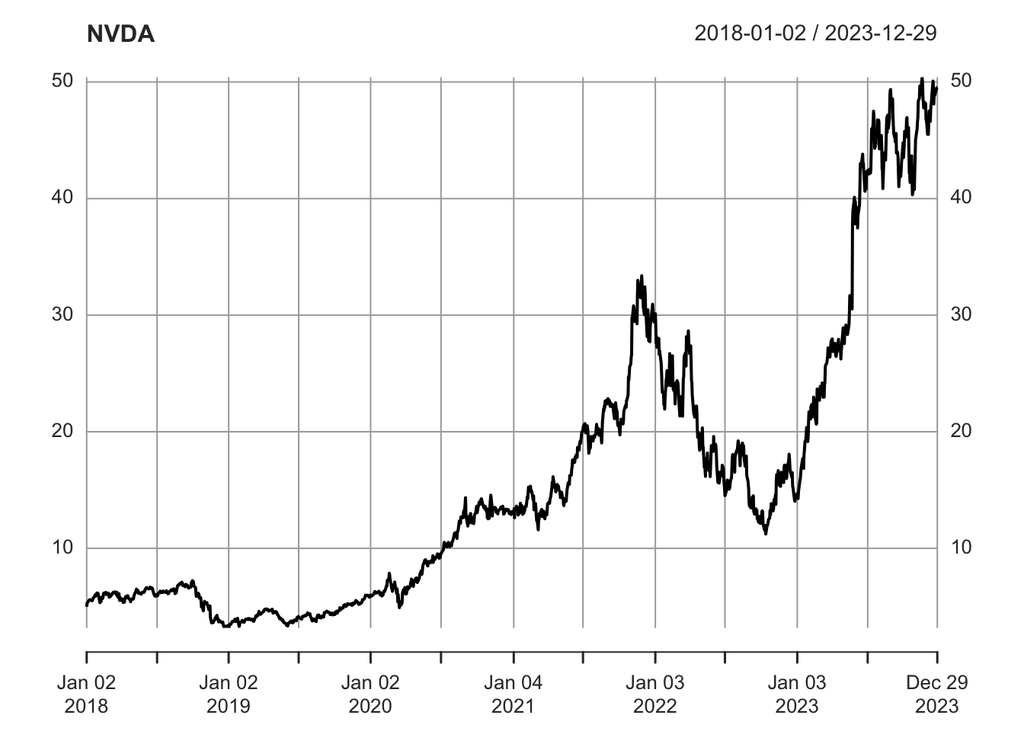

```r
NVDA <- getSymbols("NVDA", from = "2018-01-01", to = "2023-12-31",
                    src = "yahoo", auto.assign = FALSE)
NVDA <- Cl(NVDA)  # prix de clôture ajustés
plot(NVDA)
```

2. Calculez le rendement simple et le log-rendement journaliers (`quantmod::dailyReturn`, arguments `type = "arithmetic"` et `type = "log"`). Tracez les deux séries sur le même graphique : sont -elles visuellement distinguables ?
3. Calculez, pour chaque série de rendements, l’écart maximal en valeur absolue entre rendement simple et log-rendement sur tout l’échantillon. À quel type de journée (forte ou faible variation) correspond ce maximum ? Est-ce cohérent avec l’approximation $R_t \simeq \tilde R_t$ vue en cours ?

# Exercice 2 — Prix vs rendements : stationnarité visuelle

1. Tracez le prix, puis le log-rendement, l’un au-dessus de l’autre.
2. Sur quelle série la moyenne semble-t-elle constante dans le temps ? Sur laquelle une tendance ou des ruptures de niveau sont-elles visibles ?
3. Reliez votre observation au fait stylisé 1 du cours.

# Exercice 3 — Statistiques descriptives et test de normalité

1. Calculez moyenne, écart-type, asymétrie et kurtosis des log-rendements (`moments::skewness`, `moments::kurtosis`).
2. Comparez la kurtosis obtenue à la valeur de référence sous normalité. La distribution est-elle leptokurtique ?
3. Testez formellement $H_0: K(R_t)=3$ (à la main, comme au TD1) puis la normalité conjointe par un test de Jarque-Bera (`tseries::jarque.bera.test`). Les deux concluent-elles dans le même sens ?
4. Tracez un histogramme des rendements avec la densité normale ajustée superposée, puis un QQ-plot (`qqnorm`, `qqline`). Commentez.

# Exercice 4 — Absence d’autocorrélation des rendements

1. Tracez l’ACF et la PACF des log-rendements sur 20 retards (`acf`, `pacf`).
2. Appliquez un test de Ljung-Box (`Box.test(..., type = "Ljung-Box")`) à l’ordre 10. Concluez sur la présence d’autocorrélation linéaire.
3. Ce résultat signifie-t-il que les rendements sont indépendants dans le temps ? Justifiez en anticipant sur l’exercice suivant.

# Exercice 5 — Clustering de volatilité et effet ARCH

1. Tracez les rendements au carré (ou en valeur absolue) en fonction du temps. Observez-vous des périodes de forte et de faible amplitude regroupées dans le temps ?
2. Tracez l’ACF des rendements **au carré** sur 20 retards, et appliquez le test de Ljung-Box (ordre 10) à cette série.
3. Comparez ce résultat à celui de l’exercice 4. Quel est le nom donné à ce phénomène dans le cours, et quel chapitre le modélise explicitement ?

# Exercice 6 — Asymétrie et effet de levier (aperçu)

1. Séparez l’échantillon de rendements en deux sous-périodes : une période “calme” et une période incluant un épisode de forte baisse (une crise, par exemple 2020 pour la plupart des indices). Comparez l’écart-type des rendements sur les deux sous-périodes.
2. Calculez la corrélation entre le rendement du jour $R_t$ et la variation de volatilité réalisée du lendemain (approximée par $|R_{t+1}|$ ou $R_{t+1}^2$). Le signe obtenu est-il cohérent avec l’effet de levier décrit en cours ?
3. Ce dernier point est repris et formalisé au chapitre 3 (modèles EGARCH et GJR-GARCH) — retenez simplement l’observation empirique pour l’instant.

# Exercice 7 — Sur votre propre actif (préparation du projet)

Recommencez les exercices 3 à 5 sur un autre actif de votre choix (action, autre indice, crypto-actif). Les faits stylisés observés sont-ils aussi marqués ? Gardez ce code : il servira de point de départ pour la partie “faits stylisés” de votre projet.